# Peer-graded Assignment: Course Project 2

Abhishek Kumar

16 July 2020

# Exploratory Data Analysis with NOAA storm data

# 1. Synopsis

Storms and other severe weather events can cause both public health and economic problems for communities and municipalities. Many severe events can result in fatalities, injuries, and property damage, and preventing such outcomes to the extent possible is a key concern.

# 2. Data

This analysis involves an exploration of the U.S. National Oceanic and Atmospheric Administration's (NOAA) storm database. This data is available in the form of a comma-separated-value file compressed via the bzip2 algorithm to reduce its size. This data can be downloaded from the following link:

- [Storm Data](https://d396qusza40orc.cloudfront.net/repdata%2Fdata%2FStormData.csv.bz2) [47Mb]

The documentation on how some of the variables are constructed/defined for the database is available from below links:

- National Weather Service [Storm Data Documentation](https://d396qusza40orc.cloudfront.net/repdata%2Fpeer2_doc%2Fpd01016005curr.pdf)
- National Climatic Data Center Storm Events [FAQ](https://d396qusza40orc.cloudfront.net/repdata%2Fpeer2_doc%2FNCDC%20Storm%20Events-FAQ%20Page.pdf)

This database tracks characteristics of major storms and weather events in the United States, including when and where they occur, as well as estimates of any fatalities, injuries, and property damage. The events in the database start in the year 1950 and end in November 2011. In the earlier years of the database there are generally fewer events recorded, most likely due to a lack of good records. More recent years should be considered more complete.

# 3. Data Processing

Firstly, load sone of the required packages using the `library()` function

```r
library(dplyr)
```

```r
library(ggplot2)
library(tidyr)
```

## 3.1 Download the data

Firstly, the data was downloaded using the following commands:

```r
if(!file.exists("StormData.csv.bz2")) {
      fileUrl <- "https://d396qusza40orc.cloudfront.net/repdata%2Fdata%2FStormData.csv.bz2"
      download.file(fileUrl, destfile = "./StormData.csv.bz2")
      }
```

## 3.2 Loading the data

Since, this data is available in the form of a comma-separated-value file compressed via the bzip2 algorithm to reduce its size. The function `read.csv()` can read the `.csv.bz2` file

```r
storm.data <- read.csv(file = "StormData.csv.bz2", header = TRUE, sep = ",")
head(storm.data)
```

```
##   STATE__           BGN_DATE BGN_TIME TIME_ZONE COUNTY COUNTYNAME STATE  EVTYPE
## 1       1  4/18/1950 0:00:00     0130       CST     97     MOBILE    AL TORNADO
## 2       1  4/18/1950 0:00:00     0145       CST      3    BALDWIN    AL TORNADO
## 3       1  2/20/1951 0:00:00     1600       CST     57    FAYETTE    AL TORNADO
## 4       1   6/8/1951 0:00:00     0900       CST     89    MADISON    AL TORNADO
## 5       1 11/15/1951 0:00:00     1500       CST     43    CULLMAN    AL TORNADO
## 6       1 11/15/1951 0:00:00     2000       CST     77 LAUDERDALE    AL TORNADO
##   BGN_RANGE BGN_AZI BGN_LOCATI END_DATE END_TIME COUNTY_END COUNTYENDN
## 1         0                                               0         NA
## 2         0                                               0         NA
## 3         0                                               0         NA
## 4         0                                               0         NA
## 5         0                                               0         NA
## 6         0                                               0         NA
##   END_RANGE END_AZI END_LOCATI LENGTH WIDTH F MAG FATALITIES INJURIES PROPDMG
```

[output cut: 20 more lines]

After loading the data, the structure of data can be viewed using the `str()` function

```r
str(storm.data)
```

```
## 'data.frame':    902297 obs. of  37 variables:
##  $ STATE__   : num  1 1 1 1 1 1 1 1 1 1 ...
##  $ BGN_DATE  : chr  "4/18/1950 0:00:00" "4/18/1950 0:00:00" "2/20/1951 0:00:00" "6/8/1951 0:00:00" ...
##  $ BGN_TIME  : chr  "0130" "0145" "1600" "0900" ...
##  $ TIME_ZONE : chr  "CST" "CST" "CST" "CST" ...
##  $ COUNTY    : num  97 3 57 89 43 77 9 123 125 57 ...
##  $ COUNTYNAME: chr  "MOBILE" "BALDWIN" "FAYETTE" "MADISON" ...
##  $ STATE     : chr  "AL" "AL" "AL" "AL" ...
##  $ EVTYPE    : chr  "TORNADO" "TORNADO" "TORNADO" "TORNADO" ...
##  $ BGN_RANGE : num  0 0 0 0 0 0 0 0 0 0 ...
##  $ BGN_AZI   : chr  "" "" "" "" ...
##  $ BGN_LOCATI: chr  "" "" "" "" ...
##  $ END_DATE  : chr  "" "" "" "" ...
##  $ END_TIME  : chr  "" "" "" "" ...
##  $ COUNTY_END: num  0 0 0 0 0 0 0 0 0 0 ...
```

[output cut: 23 more lines]

So, this data is a dataframe with 902297 observations (rows) and 37 variables (columns). Also, the date and time are represented as characters, which need to be converted into Date and Time format

## 3.3 Preprocessiog

Lets convert the date and time

```r
storm.data$BGN_DATE <- as.Date(storm.data$BGN_DATE, "%m/%d/%Y")
str(storm.data)
```

```
## 'data.frame':    902297 obs. of  37 variables:
##  $ STATE__   : num  1 1 1 1 1 1 1 1 1 1 ...
##  $ BGN_DATE  : Date, format: "1950-04-18" "1950-04-18" ...
##  $ BGN_TIME  : chr  "0130" "0145" "1600" "0900" ...
##  $ TIME_ZONE : chr  "CST" "CST" "CST" "CST" ...
##  $ COUNTY    : num  97 3 57 89 43 77 9 123 125 57 ...
##  $ COUNTYNAME: chr  "MOBILE" "BALDWIN" "FAYETTE" "MADISON" ...
##  $ STATE     : chr  "AL" "AL" "AL" "AL" ...
##  $ EVTYPE    : chr  "TORNADO" "TORNADO" "TORNADO" "TORNADO" ...
##  $ BGN_RANGE : num  0 0 0 0 0 0 0 0 0 0 ...
##  $ BGN_AZI   : chr  "" "" "" "" ...
##  $ BGN_LOCATI: chr  "" "" "" "" ...
##  $ END_DATE  : chr  "" "" "" "" ...
##  $ END_TIME  : chr  "" "" "" "" ...
##  $ COUNTY_END: num  0 0 0 0 0 0 0 0 0 0 ...
```

[output cut: 23 more lines]

Now, date has been converted. Let's look at our questions

- *Across the United States, which types of events (as indicated in the `EVTYPE` variable) are most harmful with respect to population health?*
- *Across the United States, which types of events have the greatest economic consequences?*

So we need to focus on health and economic damage, therefore we do not need to process all the data, we can subset the data by selecting desirable columns.

- Health: FATALITIES and INJURIES
- Economic: PROPDMG, PROPDMGEXP, CROPDMG, CROPDMGEXP

After selecting the desirable variables, we may filter the observations, which have some impacts i.e. values greater than zero. This will results in reduced data for analysis.

```r
storm.damage <- storm.data %>%
      select(EVTYPE, FATALITIES, INJURIES, PROPDMG, PROPDMGEXP, CROPDMG, CROPDMGEXP)
```

Considering the given data, human health can be assessed by two variables i.e. FATALITIES and INJURIES. So for achieving this, * we need to first filter the data with storm events which had some impact on human health * Then, the data is grouped by EVent types * It is followed by summarising data to sum the FATALITIES and INJURIES with EVTYPE. * The data is then arranged in decreasing values of Fatalities and Injuries. * This can be achieved by using either the `aggregate()` function or using the package `dplyr`. Here, I am using the the package `dplyr` * After this, the data was tranformed into a longer format to plot with different panels

```r
fat <- storm.damage %>%
      filter(FATALITIES > 0 | INJURIES > 0) %>%
      group_by(EVTYPE) %>%
      summarise(Fatalities = sum(FATALITIES)) %>%
      arrange(desc(Fatalities))
inj <- storm.damage %>%
      filter(FATALITIES > 0 | INJURIES > 0) %>%
      group_by(EVTYPE) %>%
      summarise(Injuries = sum(INJURIES)) %>%
      arrange(desc(Injuries))
health.Dam <- merge(fat[1:10,], inj[1:10,]) %>%
      pivot_longer(-EVTYPE, names_to = "variables", values_to = "values")
```

Our Second questions was:

- *Across the United States, which types of events have the greatest economic consequences?*

So, for economid damage, we have already selected variables and stored in storm.damage dataframe.There are two types of variables that impact the economic damage i.e. Crop damage and property damage. However, this data has some exponents which are defined in CROPDAMEXP and PROPDAMEXP, respectively. So first we have decode these exponents. Lets look at unique varibales in EXPs

```r
unique(storm.damage$CROPDMGEXP)
```

```
## [1] ""  "M" "K" "m" "B" "?" "0" "k" "2"
```

```r
unique(storm.damage$PROPDMGEXP)
```

```
##  [1] "K" "M" ""  "B" "m" "+" "0" "5" "6" "?" "4" "2" "3" "h" "7" "H" "-" "1" "8"
```

Here, these symbols represent different exponents which need to be replaced in the data. * 0 = 1 * 1 = 10 * 2 = 100 * 3 = 1,000 * 4 = 10,000 * 5 = 100,000 * 6 = 1,000,000 * 7 = 10,000,000 * 8 = 100,000,000 * 9 = 1,000,000,000 * H = 100 * h = 100 * K = 1,000 * k = 1,000 * M = 1,000,000 * m = 1,000,000 * B = 1,000,000,000 * + = 1 * "" = 1 * - = 1

```r
storm.damage$CropFactor[(storm.damage$CROPDMGEXP == "")] <- 10^0
storm.damage$CropFactor[(storm.damage$CROPDMGEXP == "M")] <- 10^6
storm.damage$CropFactor[(storm.damage$CROPDMGEXP == "K")] <- 10^3
storm.damage$CropFactor[(storm.damage$CROPDMGEXP == "m")] <- 10^6
storm.damage$CropFactor[(storm.damage$CROPDMGEXP == "B")] <- 10^9
storm.damage$CropFactor[(storm.damage$CROPDMGEXP == "?")] <- 10^0
storm.damage$CropFactor[(storm.damage$CROPDMGEXP == "0")] <- 10^0
storm.damage$CropFactor[(storm.damage$CROPDMGEXP == "k")] <- 10^3
storm.damage$CropFactor[(storm.damage$CROPDMGEXP == "2")] <- 10^2

storm.damage$PropFactor[(storm.damage$PROPDMGEXP == "K")] <- 10^3
storm.damage$PropFactor[(storm.damage$PROPDMGEXP == "M")] <- 10^6
storm.damage$PropFactor[(storm.damage$PROPDMGEXP == "")] <- 10^0
storm.damage$PropFactor[(storm.damage$PROPDMGEXP == "B")] <- 10^9
storm.damage$PropFactor[(storm.damage$PROPDMGEXP == "m")] <- 10^6
storm.damage$PropFactor[(storm.damage$PROPDMGEXP == "+")] <- 10^0
storm.damage$PropFactor[(storm.damage$PROPDMGEXP == "0")] <- 10^0
storm.damage$PropFactor[(storm.damage$PROPDMGEXP == "5")] <- 10^5
storm.damage$PropFactor[(storm.damage$PROPDMGEXP == "6")] <- 10^6
storm.damage$PropFactor[(storm.damage$PROPDMGEXP == "?")] <- 10^0
storm.damage$PropFactor[(storm.damage$PROPDMGEXP == "4")] <- 10^4
storm.damage$PropFactor[(storm.damage$PROPDMGEXP == "2")] <- 10^2
storm.damage$PropFactor[(storm.damage$PROPDMGEXP == "3")] <- 10^3
storm.damage$PropFactor[(storm.damage$PROPDMGEXP == "h")] <- 10^2
storm.damage$PropFactor[(storm.damage$PROPDMGEXP == "7")] <- 10^7
storm.damage$PropFactor[(storm.damage$PROPDMGEXP == "H")] <- 10^2
storm.damage$PropFactor[(storm.damage$PROPDMGEXP == "-")] <- 10^0
storm.damage$PropFactor[(storm.damage$PROPDMGEXP == "1")] <- 10^1
storm.damage$PropFactor[(storm.damage$PROPDMGEXP == "8")] <- 10^8
```

So after replacing the factors, we can now calculate the economic damage * we introduce a new variable called EconDam which is equal to total economic loss due to crop and property damage by storms. For this, we need to multiply the damage by the transformed factors thus * EconDam = (CROPDMG x CropFactor) + (PROPDMG x PropFactor)

- then we have first filtered values which had some impact on economy
- then grouped by Event type and finally
- summarised by sum and arranged in decreasing order

```r
Econ.Dam <- storm.damage %>% mutate(EconDam = (CROPDMG * CropFactor) + (PROPDMG * PropFactor)) %>%
      filter(EconDam > 0) %>%
      group_by(EVTYPE) %>%
      summarise(EconLoss = sum(EconDam)) %>%
      arrange(desc(EconLoss))
```

```r
Econ.Dam$EconLoss <- Econ.Dam$EconLoss/10^9
```

Now, the economic values are conerted into billions USD, So, this data is ready for our question.

# 4. Results

So, now we can plot Health Damage against the storm event type, to see the highest impact on Human health.

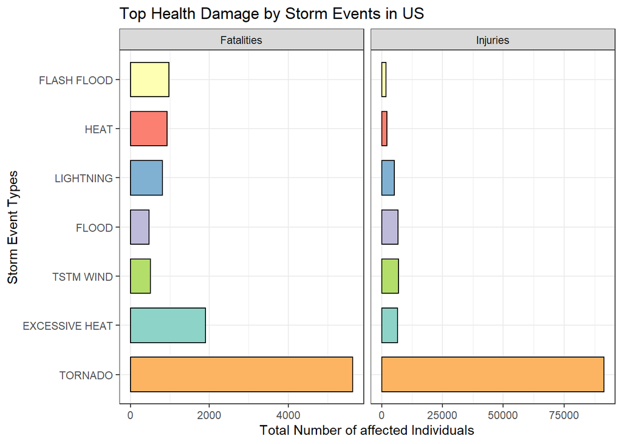

```r
ggplot(data = health.Dam, aes(x = reorder(EVTYPE, -values), y = values, fill = EVTYPE)) +
      geom_bar(stat = "identity", width = 0.7, color = "black", show.legend = FALSE) +
      scale_fill_brewer(palette = "Set3")+
      facet_wrap(~variables, scales = "free_x") +
      labs(x = "Storm Event Types", y = "Total Number of affected Individuals") +
      ggtitle("Top Health Damage by Storm Events in US") +
      coord_flip() +
      theme_bw()
```

This figures clearly shows that Tornados are most harmfuls storm events in US. In both type of Human health impact, Tornados have the most devastating effects on Human health

So, now we can plot Economic Damage against the storm event type, to see the highest impact on Economy.

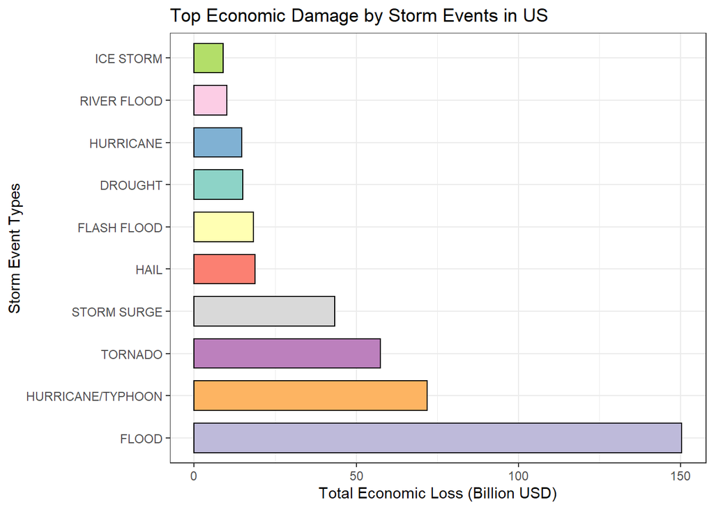

```r
ggplot(data = Econ.Dam[1:10,], aes(x = reorder(EVTYPE, -EconLoss), y = EconLoss, fill = EVTYPE)) +
      geom_bar(stat = "identity", width = 0.7, color = "black", show.legend = FALSE) +
      scale_fill_brewer(palette = "Set3")+
      labs(x = "Storm Event Types", y = "Total Economic Loss (Billion USD)") +
      ggtitle("Top Economic Damage by Storm Events in US") +
      coord_flip() +
      theme_bw()
```

Thus, the above figure clearly show that Floods cause highest economic loss in US, which correspons to more than 150 Billion USD. This amount is almost double to the economic loss caused by Hurricanes or Typhoons.

# 5. Conclusion

In conclusion, Our data analysis clealry depicted that Tornaodos causes highest damage to human health including fatalities and injuries whereas Floods cause highest economic loss in US. Therefore, the government or municipal should focus on preparing for severe weather events and will need to prioritize resources for Tornados and Flood types of events.